# 3a_compositing

```python
!pip install pywapor --quiet
```

[output not shown]

### Composites

In this notebook we'll take a closer look at how `pre_et_look` works internally. To do so, we'll be using a couple of functions that you'd normally not need to touch, because they are called automatically when you run `pywapor.pre_et_look.main`.

```python
import pywapor

folder = r"/Users/hmcoerver/Local/3_compositing"
latlim = [28.9, 29.7]
lonlim = [30.2, 31.2]
timelim = ["2021-06-01", "2021-08-01"]
```

Previously, we had a closer look at the keyword-argument `sources`. Here we'll look at another keyword-argument that controls how the "time_bins" or "composites" are configured. We can look at the documentation again like this.

```python
help(pywapor.pre_et_look.main)
```

```
Help on function main in module pywapor.pre_et_look:

main(folder, latlim, lonlim, timelim, sources='level_1', bin_length='DEKAD', enhancers=[<function lapse_rate at 0x7f34d6ff28b0>])
    Prepare input data for `et_look`.

    Parameters
    ----------
    folder : str
        Path to folder in which to store (intermediate) data.
    latlim : list
        Latitude limits of area of interest.
    lonlim : list
        Longitude limits of area of interest.
    timelim : list
        Period for which to prepare data.
    sources : "level_1" | "level_2" | "level_2_v3" | dict, optional
        Configuration for each variable and source, by default `"level_1"`.
    bin_length : int | "DEKAD", optional
        Composite length, by_default `"DEKAD"`.
    enhancers : list, optional
        Functions to apply to the xr.Dataset before creating the final
        output, by default `[lapse_rate]`.

    Returns
    -------
    xr.Dataset
        Dataset with input data for `pywapor.et_look`.
```

> **Question**
> - Which keyword-argument control the composite length?
> - What is its default value?

> **Answer**
> - `bin_length`.
> - `"DEKAD`.

One of the first things happening when you run `pre_et_look`, is the creation of a more precise definition of the composites (from here on also referred to as time_bins) for which `pre_et_look` will prepare the data to be used by `et_look`.

By combining the period we've selected (i.e. `timelim`) and the `bin_length` we've chosen, `pre_et_look` will create the bins using the function `pywapor.general.compositer.time_bins`. We can run it like this.

```python
bin_length = "DEKAD"

bins = pywapor.general.compositer.time_bins(timelim, bin_length)
```

> **Question**
> - What does the variable `bins` contain?
> - What is the length of `bins`?

```python
# Check out bins here.
bins
```

```
array(['2021-06-01T00:00:00.000000000', '2021-06-11T00:00:00.000000000',
       '2021-06-21T00:00:00.000000000', '2021-07-01T00:00:00.000000000',
       '2021-07-11T00:00:00.000000000', '2021-07-21T00:00:00.000000000',
       '2021-08-01T00:00:00.000000000'], dtype='datetime64[ns]')
```

```python
len(bins)
```

```
7
```

After defining the bins, `pre_et_look` will start collecting the different datasources. It does this with a function called `pywapor.collect.downloader.collect_sources`.

In a previous exercise, we saw that we can get more "information" about a level by calling the following function.

```python
lvl1_info = pywapor.general.levels.pre_et_look_levels("level_1")
```

`collect_sources` uses the information stored in `lvl1_info` to determine what to download and how to pre-process that data. In this exercise we don't want all the data needed by `et_look` to download. Instead, we'll only download NDVI data. To do that we'll have to remove some information from `lvl1_info`.

> **Question**
> - Which keys does lvl1_info contain?
> - Note: check the Python intro notebook if you forgot how to list a dictionaries keys.

```python
# List the keys of lvl1_info
lvl1_info.keys()
```

```
dict_keys(['ndvi', 'r0', 'se_root', 'p', 'z', 'ra', 't_air', 't_air_max', 't_air_min', 'u2m', 'v2m', 'qv', 'p_air', 'p_air_0', 'wv', 'land_mask', 'rs_min', 'z_obst_max', 'lw_offset', 'lw_slope', 'z_oro', 'rn_offset', 'rn_slope', 't_amp_year', 't_opt', 'vpd_slope'])
```

Now we will remove all the keys, except `"ndvi"` (and we override one key-value pair).

```python
selected_sources = {k: v for k, v in lvl1_info.items() if k in ["ndvi"]}

selected_sources["ndvi"]["temporal_interp"] = False

selected_sources
```

```
{'ndvi': {'products': [{'source': 'MODIS',
    'product_name': 'MOD13Q1.061',
    'enhancers': 'default',
    'is_example': True},
   {'source': 'MODIS', 'product_name': 'MYD13Q1.061', 'enhancers': 'default'}],
  'composite_type': 'mean',
  'temporal_interp': False,
  'spatial_interp': 'nearest'}}
```

> **Question**

> How many keys are left in `selected_sources`?

```python
len(selected_sources)
```

```
1
```

Now that we have filtered the sources, we can run the function `collect_sources` to download NDVI data.

```python
dss, selected_sources = pywapor.collect.downloader.collect_sources(folder, selected_sources, latlim, lonlim, timelim)
```

```
--> Collecting `ndvi` from `MODIS.MOD13Q1.061`.
```

```
NASA username: broodj3ham
NASA password: ··········
```

```
    --> Testing NASA un/pw.
    --> NASA un/pw working.
    --> Applying 'mask_qa' to `ndvi`.
    --> Saving merged data.
        > peak-memory-usage: 11.6MB, execution-time: 0:00:02.596478.
        > chunksize|dimsize: [time: 5|5, y: 403|403, x: 506|506]
        > timesize: 5 [2021-06-02T00:00, ..., 2021-08-05T00:00]
--> Collecting `ndvi` from `MODIS.MYD13Q1.061`.
    --> Applying 'mask_qa' to `ndvi`.
    --> Saving merged data.
        > peak-memory-usage: 9.3MB, execution-time: 0:00:02.168170.
        > chunksize|dimsize: [time: 4|4, y: 403|403, x: 506|506]
        > timesize: 4 [2021-06-10T00:00, ..., 2021-07-28T00:00]
```

> **Question**

> What datatype is `dss` and what does it contain?

```python
# Inspect the variables dss here.
dss
```

```
{('MODIS',
  'MOD13Q1.061'): '/Users/hmcoerver/Local/3_compositing/MODIS/MOD13Q1.061.nc',
 ('MODIS',
  'MYD13Q1.061'): '/Users/hmcoerver/Local/3_compositing/MODIS/MYD13Q1.061.nc'}
```

> **Answer**
> - `dss` is a dictionary.
> - It contains the paths to the files in which the different products are stored.

Next we'll define a new function that can plot timeseries from netcdf files.

```python
import matplotlib.pyplot as plt
import xarray as xr
import numpy as np

def plot_timeseries(dss, latlon, composites = None, var = "ndvi", unit = "-"):
    fig = plt.figure(figsize = (7, 3), dpi=100)
    ax = fig.gca()

    if not isinstance(composites, type(None)):
        x = composites.time_bins.values
        y = composites.sel(y = latlon[0], x = latlon[1], method = "nearest")[var].values
        width = np.diff(bins)
        ax.bar(x, y, width = width, align = "edge", color = "lightblue", edgecolor = "darkblue", zorder = 8, alpha = 0.8)

    for product, ds_fh in dss.items():
        ds = xr.open_dataset(ds_fh, decode_coords = "all")
        y = ds.sel(y = latlon[0], x = latlon[1], method = "nearest")[var].values
        x = ds.time.values
        ax.scatter(x, y, label = ".".join(product), zorder = 10)

    ax.legend()
    ax.grid(zorder = 0)
    ax.set_facecolor("lightgray")
    ax.set_xlabel("time")
    ax.set_ylabel(f"{var} [{unit}]")
```

> **Question**

> Which arguments does this function require?

> Which keyword-arguments can this function take?

> **Answer**
> - `dss` and `latlon`.
> - `composites`, `var` and `unit`.

With this function we can plot timeseries at a chosen point of interest. We can define a point by making a list with a latitude and a longitude value.

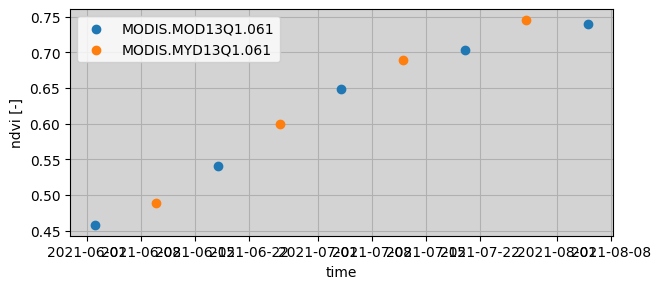

```python
latlon = [29.32301, 30.77599]
plot_timeseries(dss, latlon)
```

Next, we'll run the functions that turns these seperate measurements into composites (again, normally this is done internally when you run `pywapor.pre_et_look.main`). Note that we pass an empty list here for the `enhancers` argument, we'll get back to enhancers at a later point.

```python
enhancers = []
ds_composites = pywapor.general.compositer.main(dss, selected_sources, folder, enhancers, bins)
```

```
--> Compositing 1 variables.
    --> (1/1) Compositing `ndvi` (mean).
        --> Using `MYD13Q1.061.nc` as reprojecting example.
            > shape: (403, 506), res: 0.0020° x 0.0020°.
        --> Saving `ndvi` composites.
            > peak-memory-usage: 40.6MB, execution-time: 0:00:02.087811.
            > chunksize|dimsize: [time_bins: 6|6, y: 403|403, x: 506|506]
--> Using `MOD13Q1.061.nc` as reprojecting example.
    > shape: (403, 506), res: 0.0020° x 0.0020°.
--> Creating merged file `et_look_in.nc`.
    > peak-memory-usage: 28.0MB, execution-time: 0:00:02.174481.
    > chunksize|dimsize: [time_bins: 6|6, y: 403|403, x: 506|506]
```

> **Question**
> - What is the datatype of `ds_composites`?
> - Which dimensions and sizes does `ndvi` in `ds_composites` have. Does that correspond to what you saw in the graph above.

```python
# Inspect ds_composites here
print(type(ds_composites))
ds_composites
```

```
<class 'xarray.core.dataset.Dataset'>
```

```
<xarray.Dataset>
Dimensions:      (time_bins: 6, y: 403, x: 506)
Coordinates:
  * x            (x) float64 30.2 30.2 30.2 30.21 30.21 ... 31.19 31.2 31.2 31.2
  * y            (y) float64 29.7 29.7 29.7 29.69 ... 28.91 28.91 28.9 28.9
    spatial_ref  int64 ...
  * time_bins    (time_bins) datetime64[ns] 2021-06-01 2021-06-11 ... 2021-07-21
Data variables:
    ndvi         (time_bins, y, x) float64 dask.array<chunksize=(6, 403, 506), meta=np.ndarray>
```

> **Answer**
> - The datatype is a `xarray.Dataset`.
> - The dataset has three dimensions (`time_bins`, `x` and `y`). `x` has a size of 506, `y` has a size of 403 and `time_bins` a size of 6. In the graphs above, there were 9 temporal points, here there are only 6 left.

Now we can pass this dataset to the function we've created earlier as a keyword-argument.

> **Question**

> Re-run the function used defined earlier, but now with the keyword-argument `composites` set to `ds_composites`.

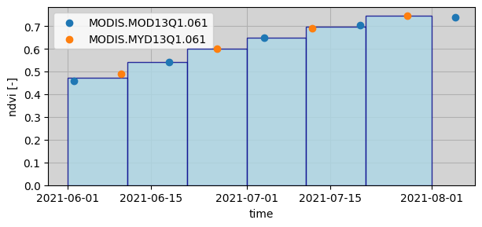

```python
# Rerun the plotting function here.
plot_timeseries(dss, latlon, composites = ds_composites)
```

In the graph we have just created, you should see a couple of things. First of all, there are blue-dots and orange-dots that show available NDVI measurements at our POI, coming from MOD13 and MYD13 respectively. Then there are blue bars that show the composite pixel values at this location.

> **Question**

> How many days wide are the blue bars

> **Answer**

> They are roughly 10 days wide.

Each composite value is the mean of the available measurements within the respective `time_bin`. For example, most of the bars match with some of the measurements. While the first bar is exactly in between two measurements, i.e. it’s the mean of the two available measurements.

> **Question**

> Now lets adjust the width of the composites, to be 6 days instead of dekadal. Can you recalculate the variable `bins` with a `bin_length` of 6 days

```python
# Recalculate the bins here
bin_length = 6

bins = pywapor.general.compositer.time_bins(timelim, bin_length)
```

> **Question**
> - What is the length of `bins`?
> - Can you recalculate the composites?

```python
len(bins)
```

```
12
```

```python
# Recalculate `ds_composites` here.
ds_composites = pywapor.general.compositer.main(dss, selected_sources, folder, enhancers, bins)
```

```
--> Compositing 1 variables.
    --> (1/1) Compositing `ndvi` (mean).
        --> Using `MYD13Q1.061.nc` as reprojecting example.
            > shape: (403, 506), res: 0.0020° x 0.0020°.
        --> Saving `ndvi` composites.
            > peak-memory-usage: 68.5MB, execution-time: 0:00:02.069883.
            > chunksize|dimsize: [time_bins: 11|11, y: 403|403, x: 506|506]
--> Using `MOD13Q1.061.nc` as reprojecting example.
    > shape: (403, 506), res: 0.0020° x 0.0020°.
--> Creating merged file `et_look_in_.nc`.
    > peak-memory-usage: 51.3MB, execution-time: 0:00:02.251936.
    > chunksize|dimsize: [time_bins: 11|11, y: 403|403, x: 506|506]
```

> **Question**

> Now make a new plot.

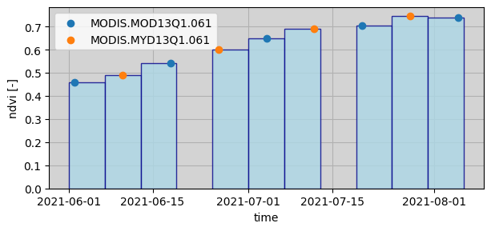

```python
#Make another plot here
plot_timeseries(dss, latlon, composites = ds_composites)
```

> **Question**

> Do you see anything unusual in this plot?

> **Answer**

> There seem to be two bins missing.

We can solve this by turning on temporal interpolation for NDVI. The temporal interpolation is defined inside the variable `selected_sources`.

> **Question**
> - Can you set the key `temporal_interp` inside `selected_sources` to `"linear"`?
> - Hint: near the beginnning of this exercise we have already set it to `False`.

```python
# Adjust the settings for tempoeral_interpolation of ndvi here.
selected_sources["ndvi"]["temporal_interp"] = "linear"
```

Now we can run the compositer again and create another plot.

```
--> Compositing 1 variables.
    --> (1/1) Compositing `ndvi` (mean).
        --> Using `MYD13Q1.061.nc` as reprojecting example.
            > shape: (403, 506), res: 0.0020° x 0.0020°.
        --> Saving `ndvi` composites.
            > peak-memory-usage: 68.5MB, execution-time: 0:00:10.100898.
            > chunksize|dimsize: [time_bins: 11|11, y: 403|403, x: 506|506]
--> Using `MOD13Q1.061.nc` as reprojecting example.
    > shape: (403, 506), res: 0.0020° x 0.0020°.
--> Creating merged file `et_look_in__.nc`.
    > peak-memory-usage: 51.4MB, execution-time: 0:00:02.281721.
    > chunksize|dimsize: [time_bins: 11|11, y: 403|403, x: 506|506]
```

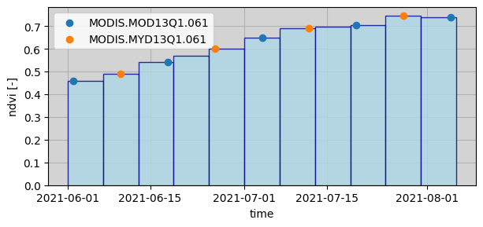

```python
ds_composites = pywapor.general.compositer.main(dss, selected_sources, folder, enhancers, bins)
plot_timeseries(dss, latlon, composites = ds_composites)
```

The two composites that were previously missing are now there! Note that although here we are looking at one pixel, these interpolations are done for the entire domain.

Possible values for `"temporal_interp"` are `False`, `"linear"`, `"nearest"`, `"zero"`, `"slinear"`, `"quadratic"` or `"cubic"`. But be aware that some of these can be computationally heavy.

#### Your turn!

> **Question**
> - What happens when you create very small or large bins?
> - Try out the other interpolation methods.
> - What happens when you change the `"composite_type"` from `"mean"` to `"max"` or `"min"`?

```
--> Compositing 1 variables.
    --> (1/1) Compositing `ndvi` (max).
        --> Using `MYD13Q1.061.nc` as reprojecting example.
            > shape: (403, 506), res: 0.0020° x 0.0020°.
        --> Saving `ndvi` composites.
            > peak-memory-usage: 42.1MB, execution-time: 0:00:08.081023.
            > chunksize|dimsize: [time_bins: 4|4, y: 403|403, x: 506|506]
--> Using `MOD13Q1.061.nc` as reprojecting example.
    > shape: (403, 506), res: 0.0020° x 0.0020°.
--> Creating merged file `et_look_in___.nc`.
    > peak-memory-usage: 18.7MB, execution-time: 0:00:02.137254.
    > chunksize|dimsize: [time_bins: 4|4, y: 403|403, x: 506|506]
```

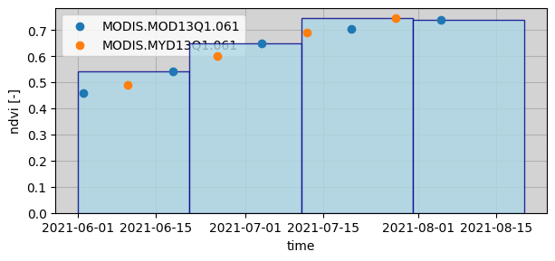

```python
bin_length = 20

bins = pywapor.general.compositer.time_bins(timelim, bin_length)

selected_sources["ndvi"]["temporal_interp"] = "nearest"
selected_sources["ndvi"]["composite_type"] = "max"

ds_composites = pywapor.general.compositer.main(dss, selected_sources, folder, enhancers, bins)
plot_timeseries(dss, latlon, composites = ds_composites)
```

```
                        --> Compositing 1 variables.
                            --> (1/1) Compositing `ndvi` (mean).
                                --> Using `MYD13Q1.061.nc` as reprojecting example.
                                    > shape: (403, 506), res: 0.0020° x 0.0020°.
                                --> Saving `ndvi` composites.
                                    > peak-memory-usage: 385.9MB, execution-time: 0:00:52.369295.
                                    > chunksize|dimsize: [time_bins: 62|62, y: 403|403, x: 506|506]
                        --> Using `MOD13Q1.061.nc` as reprojecting example.
                            > shape: (403, 506), res: 0.0020° x 0.0020°.
                        --> Creating merged file `et_look_in____.nc`.
                            > peak-memory-usage: 289.3MB, execution-time: 0:00:03.295745.
                            > chunksize|dimsize: [time_bins: 62|62, y: 403|403, x: 506|506]
```

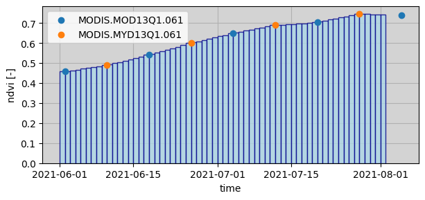

```python
bin_length = 1

bins = pywapor.general.compositer.time_bins(timelim, bin_length)

selected_sources["ndvi"]["temporal_interp"] = "slinear"
selected_sources["ndvi"]["composite_type"] = "mean"

ds_composites = pywapor.general.compositer.main(dss, selected_sources, folder, enhancers, bins)
plot_timeseries(dss, latlon, composites = ds_composites)
```